# Trp53cor1 KO vs WT (Heart)

[output not shown]

This file shows the wt-v-ko comparison for Trp53cor1.

Cuff overview:

```
## CuffSet instance with:
##   2 samples
##   26754 genes
##   77524 isoforms
##   0 TSS
##   23066 CDS
##   0 promoters
##   0 splicing
##   19954 relCDS
```

# QC

## Dispersion

Dispersion plot for genes in cuff: (Overdispersion can lead to innacurate quants)

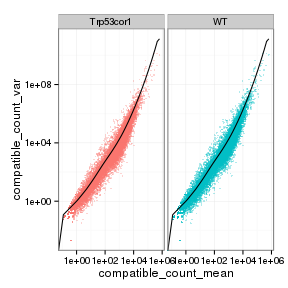

## Cross-replicate variability (fpkmSCVplot)

Differences in CV 2 can result in lower numbers of differentially expressed genes due to a higher degree of variability between replicate fpkm estimates.

Genes:

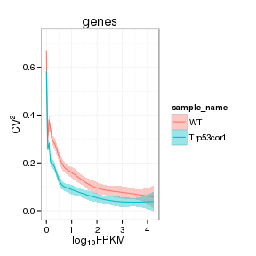

Isoforms:

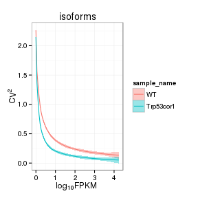

## MvA plot

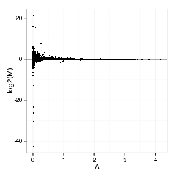

### MvA plot counts

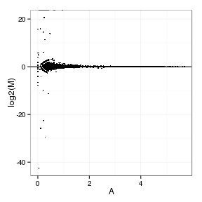

## Scatterplot matrix

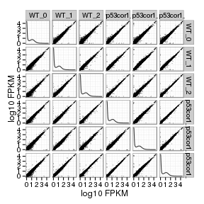

## Distributions

### Boxplots

Boxplot (genes)

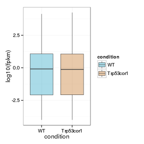

Boxplot (genes, replicates)

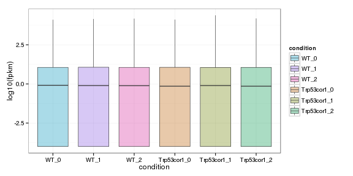

Boxplot (isoforms)

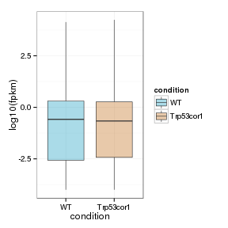

Boxplot (isoforms, replicates)

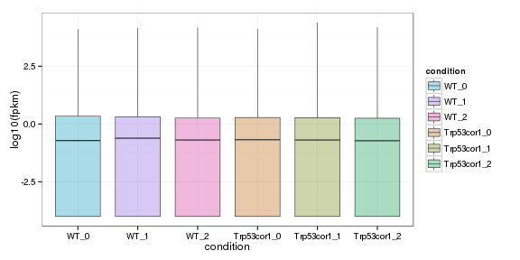

### Density

Density (genes)

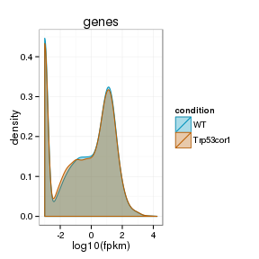

Density (genes, replicates)

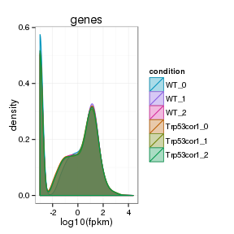

## Clustering

### Replicate Clusters

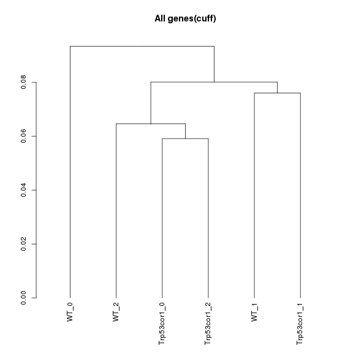

### PCA (genes)

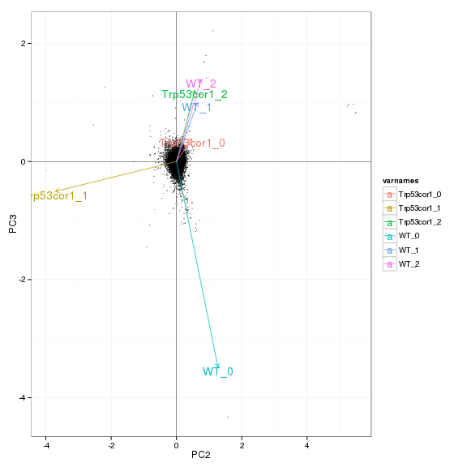

### MDS (genes)

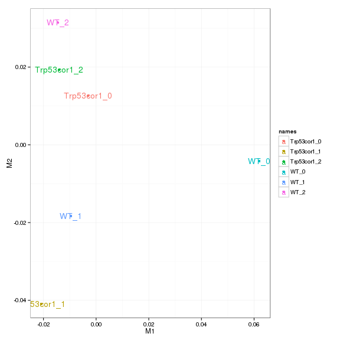

# KO assessment

## Endogenous lncRNA expression

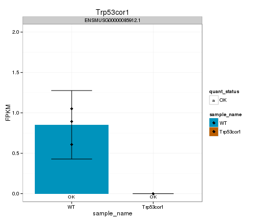

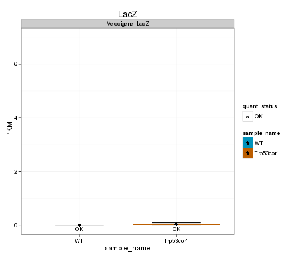

## Digital Genotyping (LacZ vs Endogenous lncRNA and Sex)

Eif2s3y is a y-expressed gene, Xist is an x-expressed gene Expression plot (endogenous linc, lacZ, Y-expressed gene):

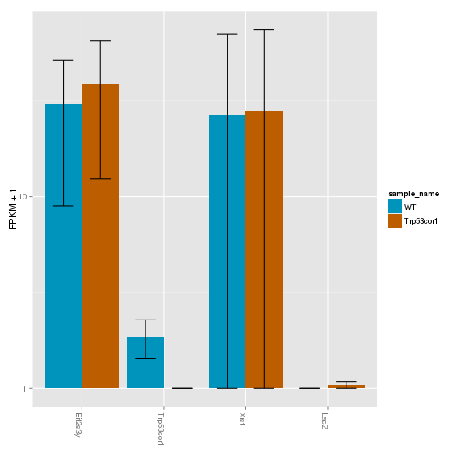

Expression heatmap:

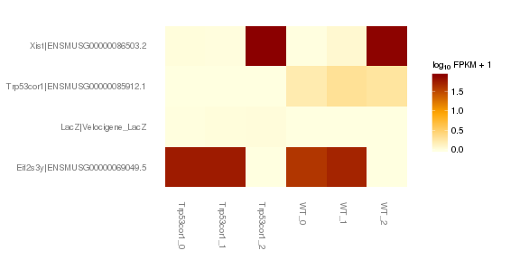

### Track visualization

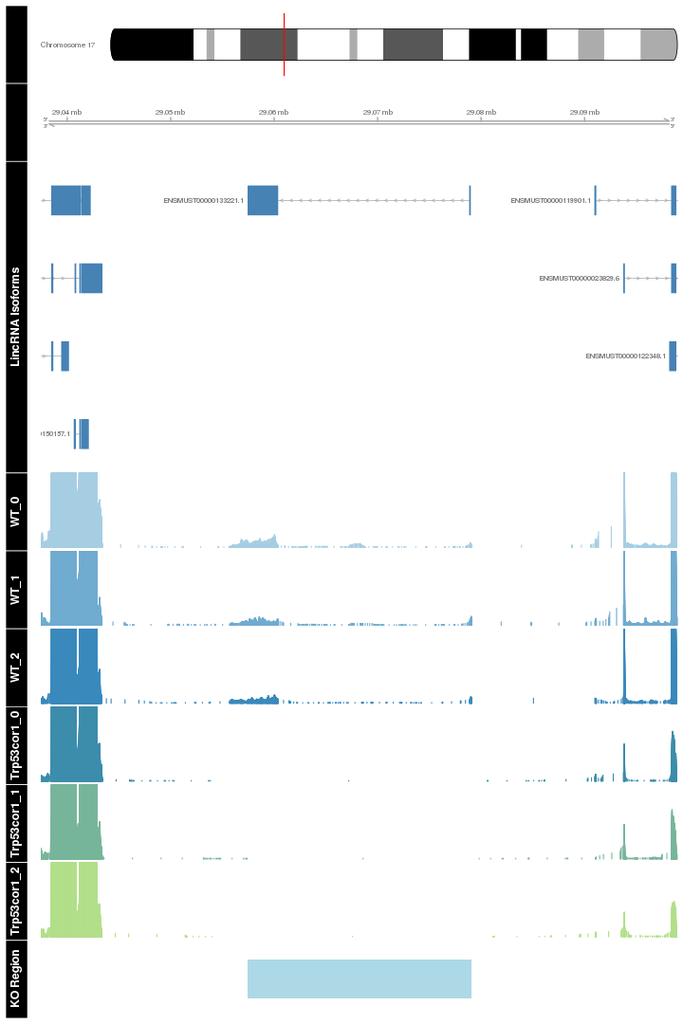

# Differential Analysis

## Differential Genes

There are 35 significantly differentially expressed genes. They are:

|  | geneAnnot$gene_short_name |
| --- | --- |
| 1 | Slc4a1 |
| 2 | Lama2 |
| 3 | Fgf12 |
| 4 | Cdkn1a |
| 5 | Glo1 |
| 6 | Fbn1 |
| 7 | Hemgn |
| 8 | Svep1 |
| 9 | Spp1 |
| 10 | Alb |
| 11 | Tnxb |
| 12 | Dnah8 |
| 13 | Rxfp1 |
| 14 | Rnps1 |
| 15 | Fras1 |
| 16 | Frem2 |
| 17 | Abcc8 |
| 18 | Hbb-bh1 |
| 19 | Vsnl1 |
| 20 | Afp |
| 21 | Uts2b |
| 22 | Fry |
| 23 | Ide |
| 24 | Dcpp3 |
| 25 | Serpina6 |
| 26 | Myl1 |
| 27 | Npw |
| 28 | Hmga1-rs1 |
| 29 | Trp53cor1 |
| 30 | Rps2-ps10 |
| 31 | Rhox5 |
| 32 | Dcpp2 |
| 33 | Gm9825 |
| 34 | Dcpp1 |
| 35 | Gm20594 |

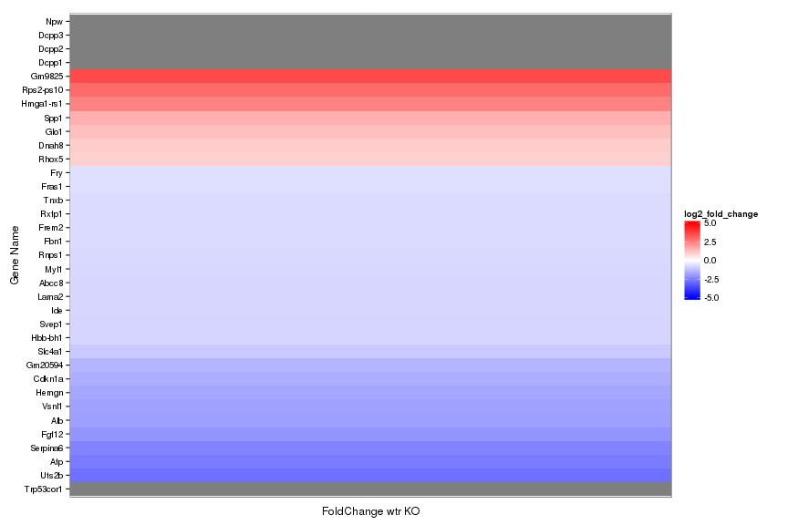

Expression heatmap of sigGenes

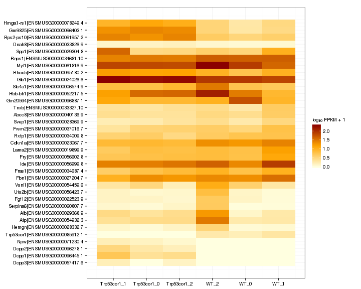

Foldchange heatmap of sigGenes

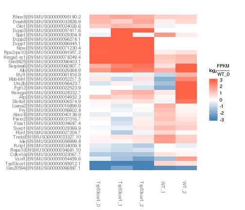

### Expression-level/significance relationship

Scatter plot of significant genes only:

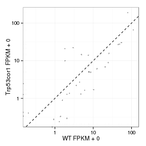

Volcano Plot

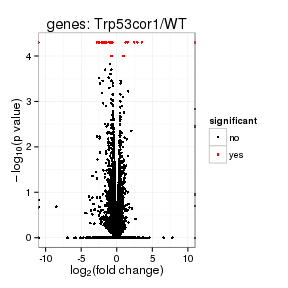

Volcano plot with significant genes only:

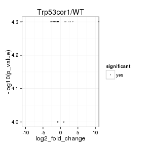

# Gene/Pathway Analysis

Enrichment and zscores are calculated based on expression in KO vs WT (fpkmKO/fpkmWT), so genes that are down regulated in KO are shown in blue, while upregulation is shown in red.

KO/WT Blue = down in KO Red = Up in KO

Biocarta enrichment:

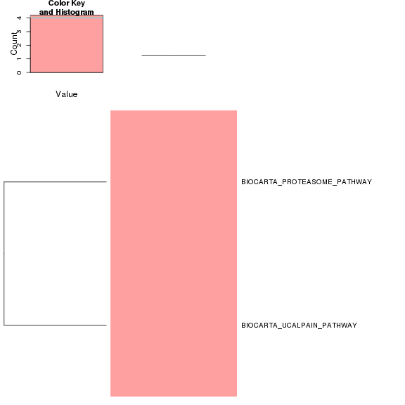

Biocarta zscore:

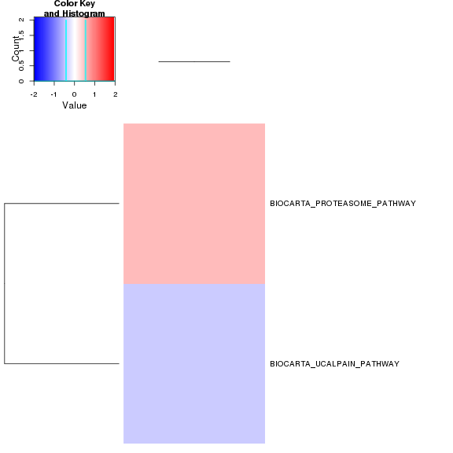

Reactome enrichment:

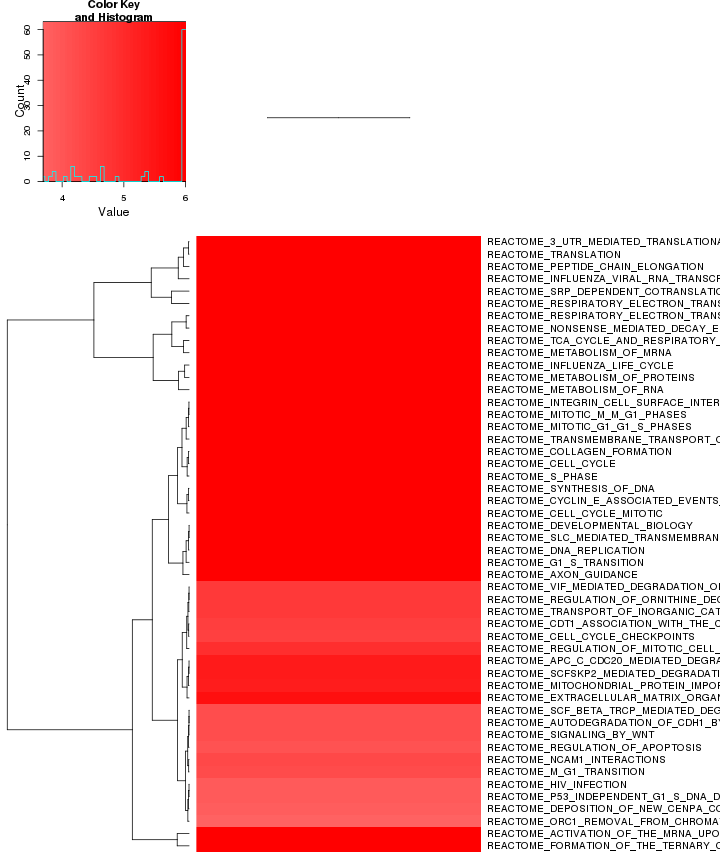

Reactome zscore:

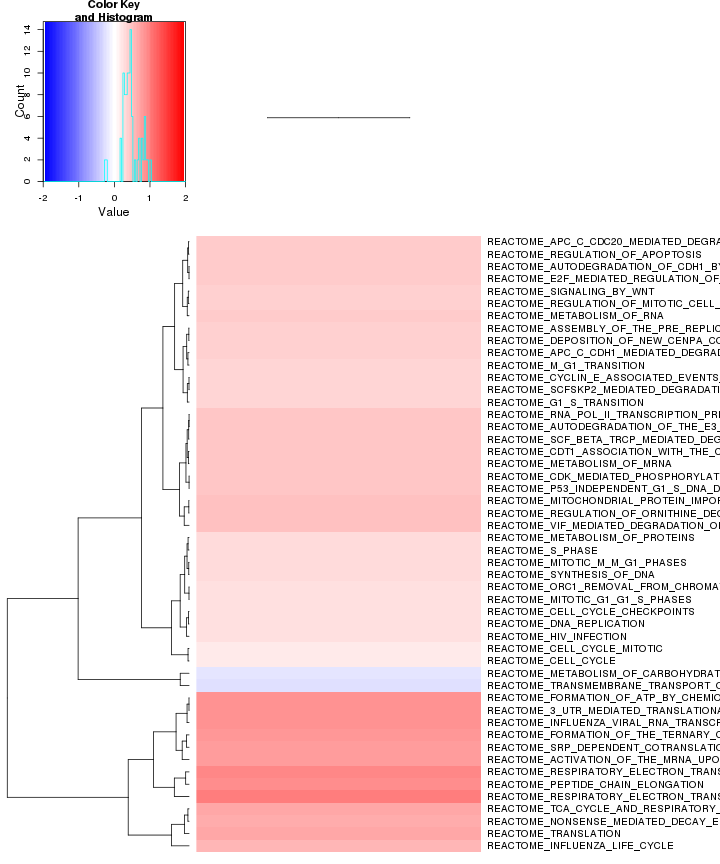

p53 enrichment:

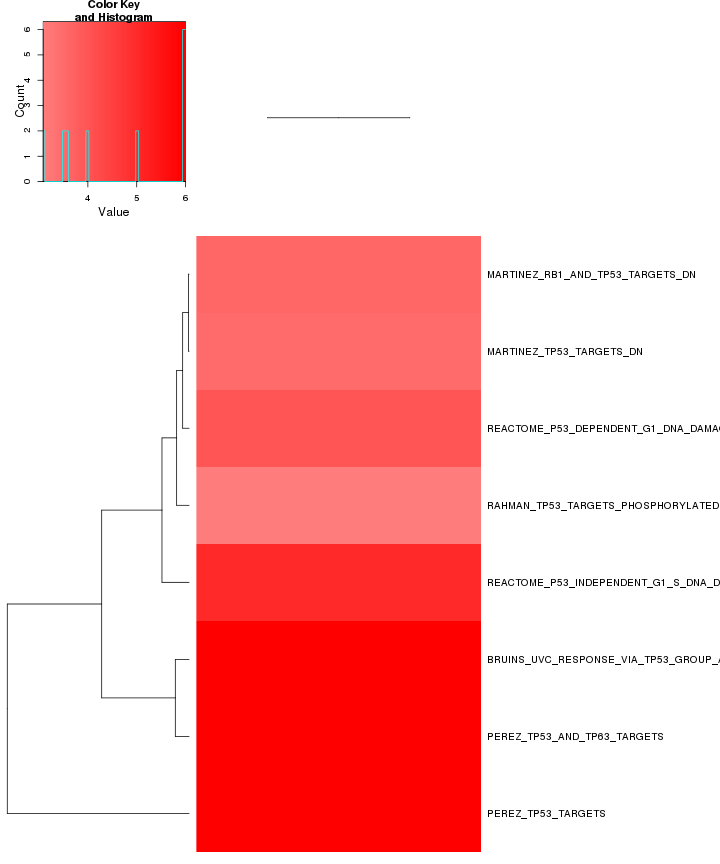

p53 zscore:

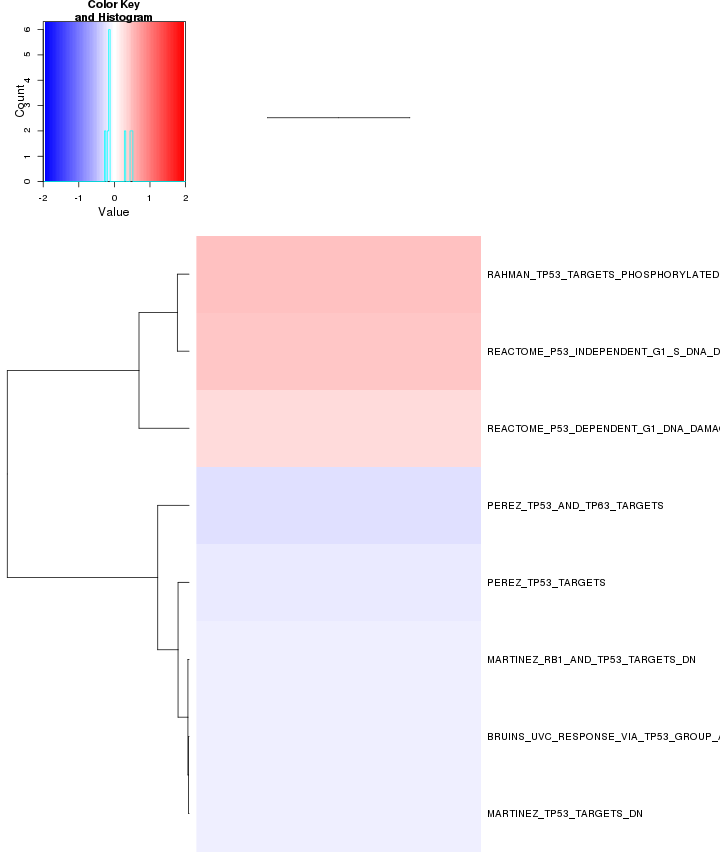

## GO enrichment

Cluster profiler used to call enichments of significantly differentially regulated genes that map to Entrez IDs.

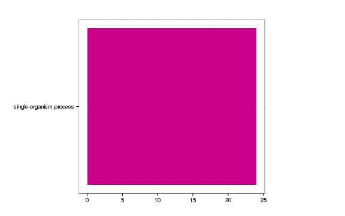

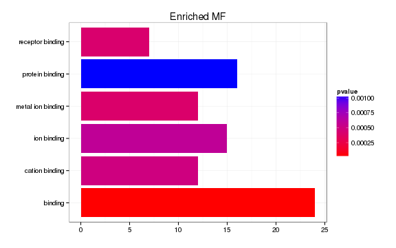

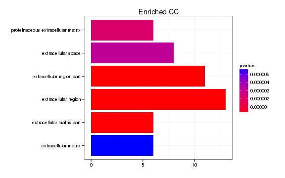

[output not shown]

[output not shown]

# Cis vs Trans (locally)

log2 Foldchange and test statistic are calculated with the ratio of fpkm(KO)/fpkm(WT), thus the test_stat is positive if a gene is higher in the KO and negative if a gene has lower expression in the KO

The pvalue for genes significantly regulated in a region this size is: 0.0073

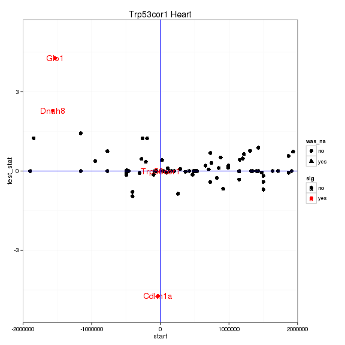

# Notes

## Samples used are:

|  | 11 |
| --- | --- |
| 1 | JR919 |
| 2 | JR927 |
| 3 | JR935 |
| 4 | JR920 |
| 5 | JR928 |
| 6 | JR936 |

## Replicates

|  | file | sample_name | replicate | rep_name | total_mass | norm_mass | internal_scale | external_scale |
| --- | --- | --- | --- | --- | --- | --- | --- | --- |
| 1 | /n/rinn_data1/users/agroff/seq/OtherMice/Diana/lincP21/quants/JR919/abundances.cxb | WT | 0 | WT_0 | 13208700.00 | 34770500.00 | 0.39 | 1.00 |
| 2 | /n/rinn_data1/users/agroff/seq/OtherMice/Diana/lincP21/quants/JR927/abundances.cxb | WT | 1 | WT_1 | 37517100.00 | 34770500.00 | 1.07 | 1.00 |
| 3 | /n/rinn_data1/users/agroff/seq/OtherMice/Diana/lincP21/quants/JR935/abundances.cxb | WT | 2 | WT_2 | 42610300.00 | 34770500.00 | 1.21 | 1.00 |
| 4 | /n/rinn_data1/users/agroff/seq/OtherMice/Diana/lincP21/quants/JR920/abundances.cxb | Trp53cor1 | 0 | Trp53cor1_0 | 47074400.00 | 34770500.00 | 1.40 | 1.00 |
| 5 | /n/rinn_data1/users/agroff/seq/OtherMice/Diana/lincP21/quants/JR928/abundances.cxb | Trp53cor1 | 1 | Trp53cor1_1 | 43574500.00 | 34770500.00 | 1.20 | 1.00 |
| 6 | /n/rinn_data1/users/agroff/seq/OtherMice/Diana/lincP21/quants/JR936/abundances.cxb | Trp53cor1 | 2 | Trp53cor1_2 | 40387600.00 | 34770500.00 | 1.16 | 1.00 |

## Run Info

[output not shown]